# Assignment 6

Kimberly Juarez-Rico

12/7/2021

The purpose of this report is to use Public Use Microdata Survey (PUMS) data to conduct a housing burden cost analysis and to use San Francisco open source parcel data to determine the amount of unused parcel space within a district of San Francisco that could potentially be used as a development space.

Part 1: For part 1 of the analysis I chose to analyze the housing burden costs for rented in Sonoma County and how much it would cost to relieve that cost from the renters through government programs.

Installed the necessary libraries, Census key, and Mapbox access token:

```r
library(tidyverse)
library(tigris)
library(tidycensus)
library(sf)
library(leaflet)
library(mapboxapi)
library(readxl)
library(dplyr)
library(tidyr)
census_api_key("4f290b276a2a5526b13d917c76884e70b99ba725")
mb_access_token("pk.eyJ1Ijoia2p1YXJlenJpY28iLCJhIjoiY2tnamx6YXUyMDhlZTMxbDh3cjR2cnJzcSJ9.GfWXcAN9I6phMo8Kg08pFw", overwrite=T, install=T)
```

```
## [1] "pk.eyJ1Ijoia2p1YXJlenJpY28iLCJhIjoiY2tnamx6YXUyMDhlZTMxbDh3cjR2cnJzcSJ9.GfWXcAN9I6phMo8Kg08pFw"
```

```r
readRenviron("~/.Renviron")
```

Creates an index of PUMAS data based on geometry centroids for Sonoma County and downloads PUMS 5 year ACS data:

```r
soco <- "Sonoma"
soco_name <-
  counties("CA", cb = T, progress_bar = F) %>%
  filter(NAME %in% soco)
ca_pumas <-
  pumas("CA", cb = T, progress_bar = F)
soco_pumas <-
  ca_pumas %>%
  st_centroid() %>%
  .[soco_name, ] %>%
  st_set_geometry(NULL) %>%
  left_join(ca_pumas %>% select(GEOID10)) %>%
  st_as_sf()
pums_vars_2018 <-
  pums_variables %>%
  filter(year == 2018, survey == "acs5")
```

Filters PUMA data for weighting of income and housing cost for renters and owners as shown by the variables “PUMA”, “GRNTP”, and “HINCP”. (I downloaded more data than required in case I decided to use it in the future.):

```r
ca_pums_housing <- get_pums(
  variables = c(
    "PUMA",
    "GRNTP",
    "ADJHSG",
    "SMOCP",
    "HINCP",
    "ADJINC",
    "HISP"
  ),
  state = "CA",
  year = 2018,
  survey = "acs5"
)
```

[output not shown]

[output cut: 23388 more lines]

[output not shown]

```r
saveRDS(ca_pums_housing,"ca_pums_housing")
soco_pums_housing <-
  ca_pums_housing %>%
  filter(PUMA %in% soco_pumas$PUMACE10)
```

I decided to keep the burden threshhold to 30% of a person’s income because a typical metric for good long term financing is to keep rent and/or other housing payments to 30% of ones income (CNBC) and then filter the income of renters (income), housing cost / income as a metric of housing burden (burden_perc_renters), the number of renters with a burden of 30 (burden_30_renters), and income gap that renters need in order to meet only having 30% of their income go to housing costs (income_gap_30_renters):

```r
burden_threshold <- 0.3
soco_burden <-
  soco_pums_housing %>%
  filter(HINCP > 0) %>%
  filter(SPORDER == 1) %>%
  transmute(
    puma = PUMA,
    weight = WGTP,
    hcost_renters = ifelse(
      GRNTP > 0,
      GRNTP*12*as.numeric(ADJHSG),
      GRNTP == 0
  ),
    income = HINCP*as.numeric(ADJINC),
    burden_perc_renters = hcost_renters/income,
    burden_30_renters = hcost_renters - burden_threshold*income,
    incomegap_30_renters = hcost_renters/burden_threshold - income
  )
```

This data set then takes the individual results and coverts them to be analyzed on a county wide level:

```r
soco_burden_pumas <-
  soco_burden %>%
  mutate(
    burdened_30 = ifelse(
      burden_perc_renters >= burden_threshold,
      weight,
      0
    ),
    excess_30 = ifelse(
      burden_30_renters < 0,
      burden_30_renters,
      0
    ),
    burden_30 = ifelse(
      burden_30_renters> 0,
      burden_30_renters,
      0
    ),
    incomegap_30 = ifelse(
      incomegap_30_renters > 0,
      incomegap_30_renters,
      0
    )
  ) %>%
  group_by(puma) %>%
  summarize(
    burdened_30 = sum(burdened_30),
    households = sum(weight),
    burden_30 = sum(burden_30*weight),
    incomegap_30 = sum(incomegap_30*weight),
    excess_30 = sum(excess_30*weight)
  ) %>%
  mutate(
    burdened_30_perc = burdened_30/households
  ) %>%
  left_join(soco_pumas %>% select(puma = PUMACE10)) %>%
  st_as_sf()
sum(soco_burden_pumas$burdened_30)/sum(soco_burden_pumas$households)
```

```
## [1] 0.2034618
```

```r
sum(soco_burden_pumas$burden_30)
```

```
## [1] 317740484
```

This map then shows the locations of where people face housing burden by using leaflet maps:

```r
burden_pal1 <- colorNumeric(
  palette = "Purples",
  domain = soco_burden_pumas$burdened_30_perc
)
soco_burden_pumas %>%
  leaflet() %>%
  addMapboxTiles(
    style_id = "streets-v11",
    username = "mapbox"
  ) %>%
  addPolygons(
    fillColor = ~burden_pal1(burdened_30_perc),
    fillOpacity = 0.5,
    color = "white",
    weight = 0.5,
    label = ~paste0(round(burdened_30_perc*100), "% of households paying 30%+
                    of income on housing"),
    highlightOptions = highlightOptions(
      weight = 2
    )
  ) %>%
  addLegend(
    pal = burden_pal1,
    values = ~burdened_30_perc,
    title = "% Cost-burdened<br>households"
  )
```

[interactive chart not shown]

Part 2: For part 2, I decided to do an analysis of the parcel availability for the Mission District of San Francisco.

San Francisco makes its parcel data publicly available which is not usually true for cities. I tried to find something like the data SF has for Sonoma County, specifically for Santa Rosa, but was unsuccessful.

SF’s open data website (https://data.sfgov.org/api/geospatial/acdm-wktn?method =export&format=GeoJSON) as shown allows for access to SF geospatial data that includes parcel shape and zoning data of SF. Zoning data is important because SF is divided into “districts” which are a better measurement of parcels. Since parcels are physical locations, it is better to use data provided by the city instead of PUMS data that gives more information about people themselves.

This loads data from open source SF data sets that give the parcel description (business, residence, etc.), the parcel zone, api, and geometry:

```r
sf_parcels_shape <-
  st_read("https://data.sfgov.org/api/geospatial/acdm-wktn?method=export&format=GeoJSON") %>%
  filter(active == "true") %>%
  select(
    apn = blklot,
    zoning = zoning_code,
    zoning_desc = zoning_district
  )
```

A temporary download file of parcels divided by district was available through: https://sfassessor.org/sites/default/files/uploaded/2020.7.10_SF_ASR_Secured_Roll_Data_2019-2020.xlsx

```r
temp <- tempfile()
download.file("https://sfassessor.org/sites/default/files/uploaded/2020.7.10_SF_ASR_Secured_Roll_Data_2019-2020.xlsx",destfile = temp, mode = "wb")
sf_secured <- read_excel(temp, sheet = "Roll Data 2019-2020")
datakey <- read_excel(temp, sheet = "Data Key")
usecode <- read_excel(temp, sheet = "Class Code Only")
unlink(temp)
```

From then, a parcel data set is created using the downloaded parcel shapes by zoning district:

```r
sf_parcels <-
  sf_parcels_shape %>%
  left_join(
    sf_secured %>%
      mutate(
        apn = RP1PRCLID %>%
          str_replace(" ","")
      )
  )
```

I used the SF open source data website to look up the tract value for the Mission District (022803) that can then be matched to the total parcel data received from open source San Francisco data.

A mission parcels is then created by matching the locations in tracts that are defined to be a part of the “Mission District” and those with the geometries in all SF parcels:

```r
mission_dist <-
  tracts("CA", "San Francisco", cb = T, progress_bar = F) %>%
  filter(
    TRACTCE %in% c(
      "022803"
    )
  ) %>%
  st_transform(4326)
mission_parcels <-
  sf_parcels %>%
  st_centroid() %>%
  .[mission_dist, ] %>%
  st_set_geometry(NULL) %>%
  left_join(sf_parcels %>% select(apn)) %>%
  st_as_sf() %>%
  filter(!is.na(RP1PRCLID))
```

This makes sure that parcels are not duplicated in the data which can lead to unrealistic results. Duplicated means that parcels are counted as two types of buildings, but they are actually only one building:

```r
duplicate_shapes <-
  mission_parcels %>%
  as.data.frame() %>%
  filter(duplicated(geometry))
condo_parcels <-
  mission_parcels %>%
  filter(geometry %in% duplicate_shapes$geometry)
```

Mission parcels can then be grouped by zone and the type of building that is not duplicated:

```r
mission_parcels %>%
  st_set_geometry(NULL) %>%
  group_by(zoning, zoning_desc) %>%
  summarize(Freq = n())
```

```
## # A tibble: 7 x 3
## # Groups:   zoning [7]
##   zoning zoning_desc                              Freq
##   <chr>  <chr>                                   <int>
## 1 NC-3   NEIGHBORHOOD COMMERCIAL, MODERATE SCALE    11
## 2 P      PUBLIC                                      5
## 3 RH-2   RESIDENTIAL- HOUSE, TWO FAMILY            251
## 4 RH-3   RESIDENTIAL- HOUSE, THREE FAMILY          269
## 5 RM-1   RESIDENTIAL- MIXED, LOW DENSITY           128
## 6 RM-2   RESIDENTIAL- MIXED, MODERATE DENSITY       25
## 7 UMU    URBAN MIXED USE                            59
```

This makes a dataset that can be easily used into the mapping interface. The zoning is mutated so that commercial buildings for the Mission DIstrict are separated by their location. From there the sum of units and floor area are calculated. The amount of stories is calculated for each parcel:

```r
mission_parcels_final <-
  mission_parcels %>%
  mutate(
    zoning = case_when(
      zoning == "RM-1|RM-2" ~ "RM-2",
      zoning_desc == "MISSION NEIGHBORHOOD COMMERCIAL" ~ "MISSION",
      zoning_desc == "MISSION NEIGHBORHOOD COMMERCIAL DISTRICT" ~ "MISSION",
      TRUE ~ zoning
    )
  ) %>%
  filter(zoning != "P") %>%
  as.data.frame() %>%
  mutate(geometry = geometry %>% st_as_text()) %>%
  group_by(geometry) %>%
  summarize(
    apn = first(apn),
    zoning = first(zoning),
    units = sum(UNITS, na.rm = T),
    stories = max(STOREYNO, na.rm = T),
    floorarea = sum(SQFT, na.rm = T)
  ) %>%
  ungroup() %>%
  select(-geometry) %>%
  left_join(mission_parcels %>% select(apn)) %>%
  st_as_sf()
```

This data set is also open source from San Francisco and provides the heights of each building directly from the website. A data set named mission_heights is created by taking the heights of the stories found in mission_parcels_final.

```r
sf_heights <- st_read("https://data.sfgov.org/resource/h9wh-cg3m.geojson")
mission_heights <-
  sf_heights[mission_parcels_final, ]
```

Finally a data set that can be projected onto a map is developed. The data set includes a calculation of the unused floor area, unused units, and unused height by calculating the max floor area, the max number of units, and the max stories available:

```r
projection <- "+proj=utm +zone=10 +ellps=GRS80 +datum=NAD83 +units=ft +no_defs"
mission_parcels_zoning <-
  mission_parcels_final %>%
  st_centroid() %>%
  st_join(mission_heights %>% select(gen_hght)) %>%
  st_set_geometry(NULL) %>%
  left_join(mission_parcels_final %>% select(apn)) %>%
  st_as_sf() %>%
  st_transform(projection) %>%
  mutate(
    lotarea = st_area(.) %>% as.numeric(),
    max_floorarea = case_when(
      zoning == "MISSION" ~ lotarea*2.5,
      zoning %in% c("MISSION","RH-1","RH-2","RH-3","RM-1","RM-2") ~ lotarea*1.8,
      zoning == "RM-3" ~ lotarea*3.6
    ),
    unused_floorarea = ifelse(
      (max_floorarea - floorarea) > 0,
      (max_floorarea - floorarea),
      0
    ),
    max_units = case_when(
      zoning %in% c("MISSION", "MISSION DISTRICT") ~ floor(lotarea/800),
      zoning == "RH-1" ~ 1,
      zoning == "RH-2" ~ 2,
      zoning == "RH-3" ~ 3,
      zoning == "RM-1" ~ pmax(3, floor(lotarea/800)),
      zoning == "RM-2" ~ pmax(3, floor(lotarea/600)),
      zoning == "RM-3" ~ pmax(3, floor(lotarea/400))
    ),
    unused_units = ifelse(
      (max_units - units) > 0,
      (max_units - units),
      0
    ),
    max_height = ifelse(
      is.na(gen_hght),
      40,
      gen_hght %>% as.numeric()
    ),
    max_stories = floor(max_height/11),
    unused_stories = ifelse(
      (max_stories - stories) > 0,
      (max_stories - stories),
      0
    )
  ) %>%
  st_transform(4326)
```

This uses the previous data set to create a map of unused floor area as shown by the increasing intensity of the green color on the map projection:

```r
floorarea_pal <- colorBin(
  palette = "Greens",
  bins = c(0,1000,5000,10000,max(mission_parcels_zoning$unused_floorarea, na.rm = T))
)
leaflet() %>%
  addMapboxTiles(
    style_id = "light-v9",
    username = "mapbox"
  ) %>%
  addPolygons(
    data = mission_parcels_zoning,
    fillColor = ~floorarea_pal(unused_floorarea),
    fillOpacity = 0.75,
    color = "white",
    weight = 0.5,
    label = ~round(unused_floorarea)
  ) %>%
  addLegend(
    data = mission_parcels_zoning,
    pal = floorarea_pal,
    values = ~unused_floorarea,
    title = "Unused Floor Area"
  )
```

[interactive chart not shown]

This creates a map of the unused units as shown by the increasing intensity of the blue color on the map projection:

```r
units_pal <- colorBin(
  palette = "Blues",
  bins = c(0,1,5,10,max(mission_parcels_zoning$unused_units, na.rm = T))
)
leaflet() %>%
  addMapboxTiles(
    style_id = "light-v9",
    username = "mapbox"
  ) %>%
  addPolygons(
    data = mission_parcels_zoning,
    fillColor = ~units_pal(unused_units),
    fillOpacity = 0.75,
    color = "white",
    weight = 0.5,
    label = ~round(unused_units)
  ) %>%
  addLegend(
    data = mission_parcels_zoning,
    pal = units_pal,
    values = ~unused_units,
    title = "Additional Units<br>Allowed"
  )
```

[interactive chart not shown]

This creates a map of the unused stories as shown by the increasing intensity of the red color on the map projection:

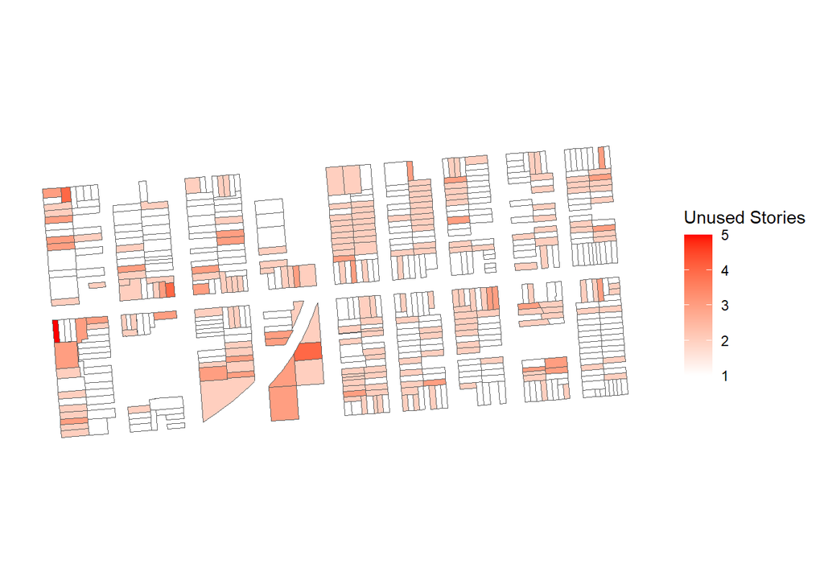

```r
stories_plot <-
  mission_parcels_zoning %>%
  filter(unused_stories > 0) %>%
  ggplot() +
  geom_sf(
    aes(
      fill = unused_stories
    ),
    lwd = 0
  ) +
  theme(
    axis.text.x = element_blank(),
    axis.text.y = element_blank(),
    axis.ticks = element_blank(),
    rect = element_blank()
  ) +
  labs(
    fill = "Unused Stories"
  ) +
  scale_fill_gradient(
    low = "white",
    high = "red"
  )
stories_plot
```

The Mission District has the potential to have additional parcels in the tract area of 022803. San Francisco and Silicon Valley are known for their expensive housing and for having a large homeless population. Analyzing the availability of parcel space can help decision makers create more affordable housing options.

Sources Used:

https://stanfordfuturebay.github.io/course/introduction.html

https://www2.census.gov/programs-surveys/acs/tech_docs/pums/data_dict/PUMS_Data_Dictionary_2018.pdf

https://data.sfgov.org/api/geospatial/acdm-wktn?method=export&format=GeoJSON

https://www.cnbc.com/2021/07/14/how-much-of-your-income-you-should-spend-on-housing.html#:~:text=The%20most%20common%20rule%20of,like%20heat%2C%20water%20and%20electricity.